# Report Project Navigation

## Deep Reinforcement Learning

### Udacity Nanodegree Program

This is a report for the first Project.

## Learning Algorithm

The report clearly describes the learning algorithm, along with the chosen hyperparameters. It also describes the model architectures for any neural networks.

The learning algorithm used is a Deep Q Learning Neural Network created with Pytorch.

The input is the vector of state.

### NN

The deep neural network has following layers:

- Input Layer: 37 (state size, from unity environment app)
  - Activation: RELU
- Hidden Layer: 64
  - Activation: RELU
- Output Layer: 4 (action size)

### Agent Params

- BUFFER_SIZE = int(1e5) # replay buffer size
- BATCH_SIZE = 128 # minibatch size
- GAMMA = 0.99 # discount factor
- TAU = 1e-3 # for soft update of target parameters
- LR = 0.001 # learning rate
- UPDATE_EVERY = 8 # how often to update the network

### DQN Algo

Parameters used in DQN algorithm:

- Maximum steps per episode: 1000
- Maximum eposides: 2000 (or it exit if score AVG > 15)
- Starting epsilion: 1.0
- Ending epsilion: 0.01
- Epsilion decay rate: 0.995

## Plot of Rewards

This is the rewards plot:

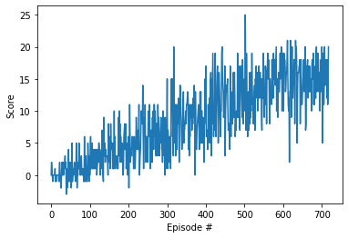

```
Episode 100 Average Score: 0.64
Episode 200 Average Score: 3.27
Episode 300 Average Score: 5.91
Episode 400 Average Score: 8.33
Episode 500 Average Score: 11.11
Episode 600 Average Score: 13.83
Episode 700 Average Score: 14.82
Episode 718 Average Score: 15.01
Environment solved in 718 episodes! Average Score: 15.01
```

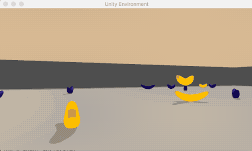

## Ideas for Future Work

This excercise can be improved by tryng some other algorithms

1. Double Deep Q Networks
2. Prioritized Experience Replay
3. Dueling Deep Q Networks
4. Learning from pixels